# Airbnb Popularity Prediction Model

1. Understanding the problem
2. Data splitting
3. EDA
4. Feature engineering
5. Preprocessing and transformations
6. Baseline model
7. Linear models
8. Different models
9. Feature selection
10. Hyperparameter optimization
11. Interpretation and feature importances
12. Results on the test set
13. Summary of the results

## Imports

```python
import matplotlib.pyplot as plt
import numpy as np
import pandas as pd
```

```python
import os
import re
import sys
sys.path.append("code/.")

from sklearn.model_selection import train_test_split
import matplotlib.pyplot as plt
import seaborn as sns
# from plotting_functions import *
from sklearn import datasets
from sklearn.compose import ColumnTransformer, make_column_transformer
from sklearn.dummy import DummyClassifier, DummyRegressor
from sklearn.ensemble import RandomForestClassifier, RandomForestRegressor
from sklearn.impute import SimpleImputer
from sklearn.linear_model import LogisticRegression, Ridge
from sklearn.model_selection import (
    GridSearchCV,
    RandomizedSearchCV,
    cross_val_score,
    cross_validate,
    train_test_split,
)
from lightgbm.sklearn import LGBMRegressor
from sklearn.tree import DecisionTreeRegressor
from sklearn.metrics import make_scorer, mean_squared_error, r2_score, mean_absolute_percentage_error
from sklearn.pipeline import Pipeline, make_pipeline
from sklearn.preprocessing import OneHotEncoder, OrdinalEncoder, StandardScaler
from sklearn.svm import SVC, SVR
from sklearn.tree import DecisionTreeClassifier
sys.path.append("code/.")
# from utils import *
```

## 1. Introduction

rubric={points:3}

In this project we'll be exploring a [dataset](https://www.kaggle.com/dgomonov/new-york-city-airbnb-open-data) of New York City Airbnb listings from 2019. We will to start by downloading the dataset. Her we'll try to predict `reviews_per_month`, as a proxy for the popularity of the listing. Airbnb could use this sort of model to predict how popular future listings might be before they are posted, perhaps to help guide hosts create more appealing listings. In reality they might instead use something like vacancy rate or average rating as their target, but we do not have that available here.

> Note there is an updated version of this dataset with more features available [here](http://insideairbnb.com/). The features were are using in `listings.csv.gz` for the New York city datasets.

Spend some time understanding the problem and what each feature means. We can find this information in the documentation on. We can find an explaination of the features [here](https://docs.google.com/spreadsheets/d/1iWCNJcSutYqpULSQHlNyGInUvHg2BoUGoNRIGa6Szc4/edit).

The New York City Airbnb dataset contains different features related to Airbnb listing such as host_information, geographical information, listing attributes, price, review and availability. The dataset contains both numeric and categorical data types which may require different preprocessing techniques and there might me missing data which we need to deal with. We will build a predictive model to predict review per month which acts as a proxy for the popularity of the listing offering insights into how various factors influence the number of reviews a listing receives. It will involve data preprocessing, feature engineering, and regression modeling to achieve the predictive goal.

```python
#Read the dataframe

df = pd.read_csv("data/AB_NYC_2019.csv", index_col =0)
df.head()
```

| id | name | host_id | host_name | neighbourhood_group | neighbourhood | latitude | longitude | room_type | price | minimum_nights | number_of_reviews | last_review | reviews_per_month | calculated_host_listings_count | availability_365 |
| --- | --- | --- | --- | --- | --- | --- | --- | --- | --- | --- | --- | --- | --- | --- | --- |
| 2539 | Clean & quiet apt home by the park | 2787 | John | Brooklyn | Kensington | 40.64749 | -73.97237 | Private room | 149 | 1 | 9 | 2018-10-19 | 0.21 | 6 | 365 |
| 2595 | Skylit Midtown Castle | 2845 | Jennifer | Manhattan | Midtown | 40.75362 | -73.98377 | Entire home/apt | 225 | 1 | 45 | 2019-05-21 | 0.38 | 2 | 355 |
| 3647 | THE VILLAGE OF HARLEM....NEW YORK ! | 4632 | Elisabeth | Manhattan | Harlem | 40.80902 | -73.94190 | Private room | 150 | 3 | 0 | NaN | NaN | 1 | 365 |
| 3831 | Cozy Entire Floor of Brownstone | 4869 | LisaRoxanne | Brooklyn | Clinton Hill | 40.68514 | -73.95976 | Entire home/apt | 89 | 1 | 270 | 2019-07-05 | 4.64 | 1 | 194 |
| 5022 | Entire Apt: Spacious Studio/Loft by central park | 7192 | Laura | Manhattan | East Harlem | 40.79851 | -73.94399 | Entire home/apt | 80 | 10 | 9 | 2018-11-19 | 0.10 | 1 | 0 |

```python
df.info()
```

```
<class 'pandas.core.frame.DataFrame'>
Index: 48895 entries, 2539 to 36487245
Data columns (total 15 columns):
 #   Column                          Non-Null Count  Dtype
---  ------                          --------------  -----
 0   name                            48879 non-null  object
 1   host_id                         48895 non-null  int64
 2   host_name                       48874 non-null  object
 3   neighbourhood_group             48895 non-null  object
 4   neighbourhood                   48895 non-null  object
 5   latitude                        48895 non-null  float64
 6   longitude                       48895 non-null  float64
 7   room_type                       48895 non-null  object
 8   price                           48895 non-null  int64
 9   minimum_nights                  48895 non-null  int64
 10  number_of_reviews               48895 non-null  int64
 11  last_review                     38843 non-null  object
 12  reviews_per_month               38843 non-null  float64
 13  calculated_host_listings_count  48895 non-null  int64
 14  availability_365                48895 non-null  int64
dtypes: float64(3), int64(6), object(6)
memory usage: 6.0+ MB
```

## 2. Data splitting

Splitting the data into train (70%) and test (30%) portions with `random_state=123`.

> Note: If the computer cannot handle training on 70% training data, make the test split bigger.

```python
X = df.drop(columns = ['reviews_per_month'], axis = 1)
y = df['reviews_per_month']
train_df, test_df = train_test_split(df, test_size = 0.3, random_state = 123)
```

## 3. EDA

```python
#Exploring types of data, seeing if there is any missing value
train_df.info()
```

```
<class 'pandas.core.frame.DataFrame'>
Index: 34226 entries, 28736148 to 12711351
Data columns (total 15 columns):
 #   Column                          Non-Null Count  Dtype
---  ------                          --------------  -----
 0   name                            34216 non-null  object
 1   host_id                         34226 non-null  int64
 2   host_name                       34209 non-null  object
 3   neighbourhood_group             34226 non-null  object
 4   neighbourhood                   34226 non-null  object
 5   latitude                        34226 non-null  float64
 6   longitude                       34226 non-null  float64
 7   room_type                       34226 non-null  object
 8   price                           34226 non-null  int64
 9   minimum_nights                  34226 non-null  int64
 10  number_of_reviews               34226 non-null  int64
 11  last_review                     27236 non-null  object
 12  reviews_per_month               27236 non-null  float64
 13  calculated_host_listings_count  34226 non-null  int64
 14  availability_365                34226 non-null  int64
dtypes: float64(3), int64(6), object(6)
memory usage: 4.2+ MB
```

```python
#This provides summary statistics (mean, standard deviation, min, max, quartiles) for all variables in the train set. It helps in understanding the distribution of the data.
train_df.describe(include = 'all')
```

|  | name | host_id | host_name | neighbourhood_group | neighbourhood | latitude | longitude | room_type | price | minimum_nights | number_of_reviews | last_review | reviews_per_month | calculated_host_listings_count | availability_365 |
| --- | --- | --- | --- | --- | --- | --- | --- | --- | --- | --- | --- | --- | --- | --- | --- |
| count | 34216 | 3.422600e+04 | 34209 | 34226 | 34226 | 34226.000000 | 34226.000000 | 34226 | 34226.000000 | 34226.000000 | 34226.000000 | 27236 | 27236.000000 | 34226.000000 | 34226.000000 |
| unique | 33662 | NaN | 9201 | 5 | 218 | NaN | NaN | 3 | NaN | NaN | NaN | 1676 | NaN | NaN | NaN |
| top | Home away from home | NaN | David | Manhattan | Williamsburg | NaN | NaN | Entire home/apt | NaN | NaN | NaN | 2019-06-23 | NaN | NaN | NaN |
| freq | 14 | NaN | 292 | 15176 | 2728 | NaN | NaN | 17848 | NaN | NaN | NaN | 984 | NaN | NaN | NaN |
| mean | NaN | 6.726273e+07 | NaN | NaN | NaN | 40.729142 | -73.952083 | NaN | 151.528399 | 7.094957 | 23.244814 | NaN | 1.369816 | 7.042453 | 112.526004 |
| std | NaN | 7.840511e+07 | NaN | NaN | NaN | 0.054531 | 0.046201 | NaN | 236.628392 | 21.548290 | 44.573323 | NaN | 1.700737 | 32.590803 | 131.420031 |
| min | NaN | 2.438000e+03 | NaN | NaN | NaN | 40.506410 | -74.244420 | NaN | 0.000000 | 1.000000 | 0.000000 | NaN | 0.010000 | 1.000000 | 0.000000 |
| 25% | NaN | 7.721897e+06 | NaN | NaN | NaN | 40.690193 | -73.983030 | NaN | 69.000000 | 1.000000 | 1.000000 | NaN | 0.190000 | 1.000000 | 0.000000 |
| 50% | NaN | 3.074526e+07 | NaN | NaN | NaN | 40.723240 | -73.955550 | NaN | 106.000000 | 3.000000 | 5.000000 | NaN | 0.710000 | 1.000000 | 45.000000 |
| 75% | NaN | 1.068375e+08 | NaN | NaN | NaN | 40.763287 | -73.936270 | NaN | 175.000000 | 5.000000 | 23.000000 | NaN | 2.000000 | 2.000000 | 225.750000 |
| max | NaN | 2.743213e+08 | NaN | NaN | NaN | 40.912340 | -73.712990 | NaN | 10000.000000 | 1250.000000 | 629.000000 | NaN | 58.500000 | 327.000000 | 365.000000 |

```python
# the count of each category in the 'neighbour_group' column. It helps in understanding the distribution  in the dataset and look for class imbalance.
train_df['neighbourhood_group'].value_counts()
```

```
neighbourhood_group
Manhattan        15176
Brooklyn         14050
Queens            3974
Bronx              771
Staten Island      255
Name: count, dtype: int64
```

```python
# the count of each category in the 'room_type' column. It helps in understanding the distribution of room types in the dataset and look for class imbalance.
train_df['room_type'].value_counts()
```

```
room_type
Entire home/apt    17848
Private room       15565
Shared room          813
Name: count, dtype: int64
```

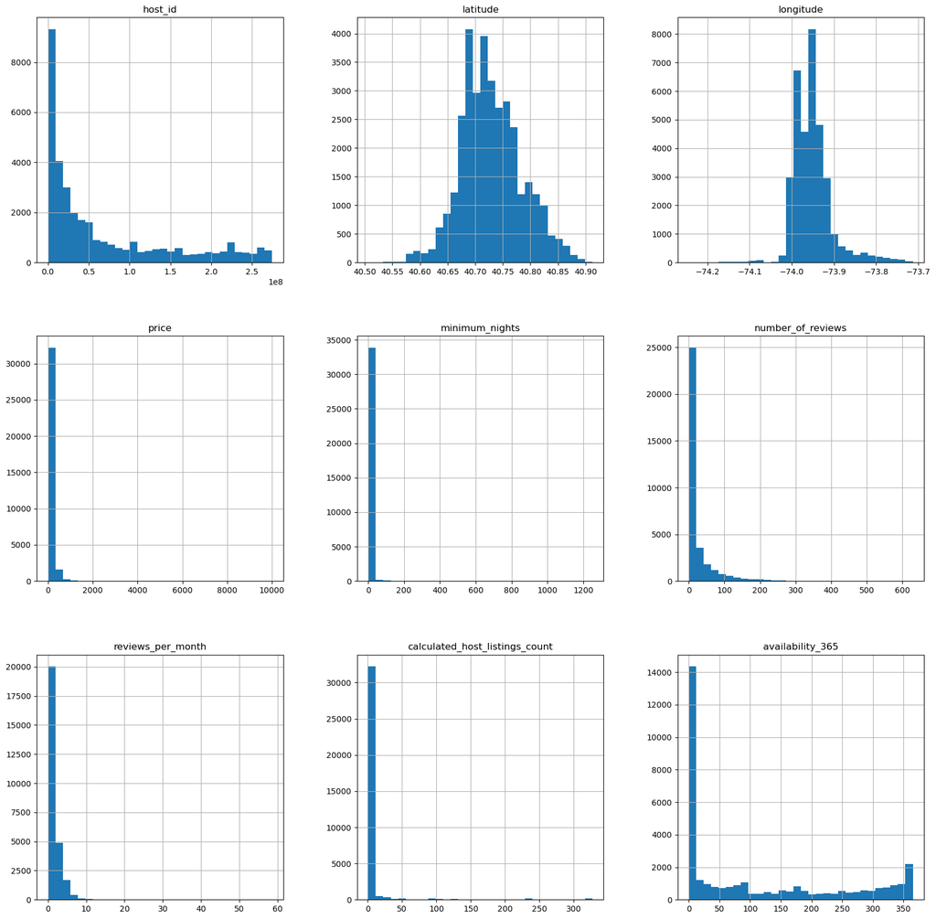

```python
#Historgram to see distribution of the features.

train_df.hist(bins = 30, figsize=(20, 20))
plt.show()
```

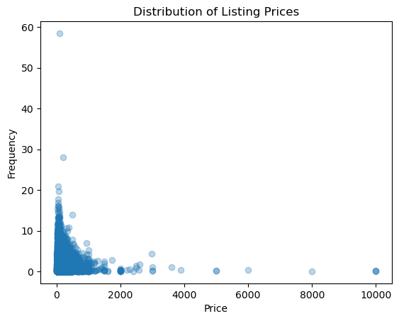

```python
#scatterplot to provide insight into the distribution of listing prices. It can help identify any outliers and the typical price range.

plt.scatter(train_df['price'], train_df['reviews_per_month'], alpha = 0.3)
plt.xlabel('Price')
plt.ylabel('Frequency')
plt.title('Distribution of Listing Prices')
plt.show()
```

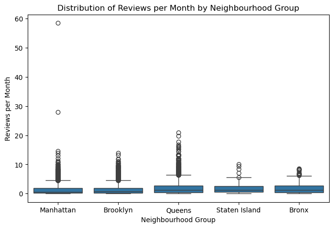

```python
# Boxplot visualizes the relationship between 'neighbourhood_group' and 'reviews_per_month', helping to identify variations in review frequencies across different neighborhoods the room is located.
plt.figure(figsize=(8, 5))
sns.boxplot(x='neighbourhood_group', y='reviews_per_month', data=train_df)
plt.xlabel('Neighbourhood Group')
plt.ylabel('Reviews per Month')
plt.title('Distribution of Reviews per Month by Neighbourhood Group')
plt.show()
```

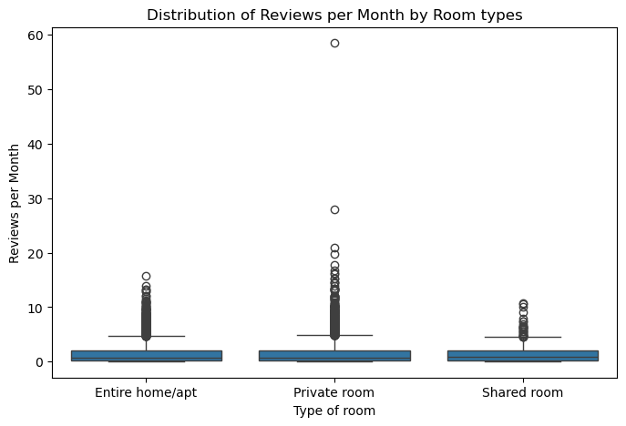

```python
# Boxplot to visualizes the relationship between 'room_type' and 'reviews_per_month', helping to identify variations in review frequencies across different types of rooms.
plt.figure(figsize=(8, 5))
sns.boxplot(x='room_type', y='reviews_per_month', data=train_df)
plt.xlabel('Type of room')
plt.ylabel('Reviews per Month')
plt.title('Distribution of Reviews per Month by Room types')
plt.show()
```

#### Initial observation

- The numeric values have different scales so it will require scaling.
- There is a class imbalance in neighborhood group and room_type class
- The histogram of the price, minimum nights, number of reviews, reviews_per_month etc. shows most values are around the average value but it is right-skewed so there may be some listings with significantly higher prices, potentially indicating outliers.
- The boxplots of 'neighbourhood_group' vs. 'reviews_per_month' and 'room_type' vs 'reviews_per_month' indicates variations in review frequencies across different neighborhood groups, with some groups having higher review rates than other and possible outliers.

#### Appropriate metrtics

Since we will be doing regression to predict 'reviews_per_month', the appropriate metrics for assessment should include regression metrics like:

- **Mean Square Error(MSE)**: MSE measures the average of the squared differences between predicted and actual values.
- **Root Mean Square Error(RMSE)**: RMSE is the square root of the average squared differences between predicted and actual values.
- **R-squared ($R^2$)**: This metric measures the proportion of the variance in the dependent variable that is predictable from the independent variables. It provides an indication of how well the model fits the data.
- **Mean Absolute Percent Error (MAPE)**: This measures the percent of average absolute difference between predicted and actual values.ata.

## Feature engineering

Carrying out feature engineering. In other words, extracting new features relevant for the problem and work with new feature set in the following steps. We may have to go back and forth between feature engineering and preprocessing.

```python
#The income for the host from an Airbnb each stay
train_df['income'] = train_df['price'] * train_df['minimum_nights']
test_df['income'] = test_df['price'] * test_df['minimum_nights']
```

```python
#Calculate the popularity of a location whether we get more reviews from a particular neighbourhood

neighbourhood_popularity = train_df.groupby('neighbourhood')['number_of_reviews'].sum().reset_index()
neighbourhood_popularity.rename(columns={'number_of_reviews': 'neighbourhood_popularity'}, inplace=True)
```

```python
#Taken help from Chatgpt to map
neighbourhood_popularity_mapping = neighbourhood_popularity.set_index('neighbourhood')['neighbourhood_popularity']

# Create a new column in the main DataFrame using .map()
train_df['neighbourhood_popularity'] = train_df['neighbourhood'].map(neighbourhood_popularity_mapping)


test_df['neighbourhood_popularity'] = test_df['neighbourhood'].map(neighbourhood_popularity_mapping)
```

```python
train_df.head(3)
```

| id | name | host_id | host_name | neighbourhood_group | neighbourhood | latitude | longitude | room_type | price | minimum_nights | number_of_reviews | last_review | reviews_per_month | calculated_host_listings_count | availability_365 | income | neighbourhood_popularity |
| --- | --- | --- | --- | --- | --- | --- | --- | --- | --- | --- | --- | --- | --- | --- | --- | --- | --- |
| 28736148 | Cozy 1 Bedroom Apt in Hamilton Heights | 43431867 | Tommy | Manhattan | Washington Heights | 40.83256 | -73.94440 | Entire home/apt | 96 | 4 | 0 | NaN | NaN | 1 | 17 | 384 | 11903 |
| 34613254 | Amazing One Bedroom at the Time Square Area/72B | 48146336 | Irina | Manhattan | Hell's Kitchen | 40.76134 | -73.99299 | Entire home/apt | 150 | 30 | 0 | NaN | NaN | 20 | 332 | 4500 | 35282 |
| 11144496 | New Spacious Master, Williamsburg | 48819868 | Nick | Brooklyn | Williamsburg | 40.71119 | -73.95097 | Private room | 200 | 1 | 0 | NaN | NaN | 1 | 0 | 200 | 56709 |

```python
test_df.head(3)
```

| id | name | host_id | host_name | neighbourhood_group | neighbourhood | latitude | longitude | room_type | price | minimum_nights | number_of_reviews | last_review | reviews_per_month | calculated_host_listings_count | availability_365 | income | neighbourhood_popularity |
| --- | --- | --- | --- | --- | --- | --- | --- | --- | --- | --- | --- | --- | --- | --- | --- | --- | --- |
| 22367196 | Sunny Bushwick Room with Holiday Sale Price! | 163554531 | Joshua | Brooklyn | Bushwick | 40.69417 | -73.91237 | Private room | 35 | 3 | 0 | NaN | NaN | 1 | 0 | 105 | 36198.0 |
| 1725295 | Midtwn E BEST LOCATION Priv Twin Rm 1 Loving Cat | 215764 | Lynn | Manhattan | Murray Hill | 40.74740 | -73.97847 | Private room | 85 | 1 | 135 | 2018-12-12 | 1.93 | 1 | 15 | 85 | 2991.0 |
| 10938202 | Spacious, bright, living/bedroom | 2455178 | Nessa | Brooklyn | Flatbush | 40.64145 | -73.96642 | Private room | 55 | 5 | 6 | 2016-11-14 | 0.17 | 1 | 0 | 275 | 9350.0 |

## 5. Preprocessing and transformations

Data cleaning will be undertaken to ensure the dataset is ready for analysis. This includes identifying and handling missing values, correcting any inconsistencies in data formats, and removing duplicate entries if they exist. Next, different feature types will be identified, including numerical, categorical, and date features. Appropriate transformations will be applied to each feature type; for instance, numerical features may be standardized or normalized, while categorical features will be one-hot encoded to facilitate analysis. If necessary, a column transformer will be defined to streamline these transformations, ensuring that each feature type is processed correctly. Additionally, the `number_of_reviews` feature will be dropped, as it is highly informative for the target variable `reviews_per_month`, making it important to assess the model's performance without direct reliance on this feature.

```python
X_train = train_df.drop(columns = ['reviews_per_month'])
y_train = train_df['reviews_per_month']

X_test = test_df.drop(columns = ['reviews_per_month'])
y_test = test_df['reviews_per_month']

X_train.head()
```

| id | name | host_id | host_name | neighbourhood_group | neighbourhood | latitude | longitude | room_type | price | minimum_nights | number_of_reviews | last_review | calculated_host_listings_count | availability_365 | income | neighbourhood_popularity |
| --- | --- | --- | --- | --- | --- | --- | --- | --- | --- | --- | --- | --- | --- | --- | --- | --- |
| 28736148 | Cozy 1 Bedroom Apt in Hamilton Heights | 43431867 | Tommy | Manhattan | Washington Heights | 40.83256 | -73.94440 | Entire home/apt | 96 | 4 | 0 | NaN | 1 | 17 | 384 | 11903 |
| 34613254 | Amazing One Bedroom at the Time Square Area/72B | 48146336 | Irina | Manhattan | Hell's Kitchen | 40.76134 | -73.99299 | Entire home/apt | 150 | 30 | 0 | NaN | 20 | 332 | 4500 | 35282 |
| 11144496 | New Spacious Master, Williamsburg | 48819868 | Nick | Brooklyn | Williamsburg | 40.71119 | -73.95097 | Private room | 200 | 1 | 0 | NaN | 1 | 0 | 200 | 56709 |
| 766814 | Adorable Midtown West Studio! | 4022922 | Caitlin | Manhattan | Hell's Kitchen | 40.75900 | -73.99530 | Entire home/apt | 95 | 1 | 0 | NaN | 1 | 0 | 95 | 35282 |
| 16162621 | NEW! Exceptional 2BR/1BA Williamsburg Oasis | 104781467 | Russell | Brooklyn | Williamsburg | 40.71306 | -73.94856 | Entire home/apt | 199 | 3 | 1 | 2016-12-11 | 1 | 0 | 597 | 56709 |

```python
X_train.columns
```

```
Index(['name', 'host_id', 'host_name', 'neighbourhood_group', 'neighbourhood',
       'latitude', 'longitude', 'room_type', 'price', 'minimum_nights',
       'number_of_reviews', 'last_review', 'calculated_host_listings_count',
       'availability_365', 'income', 'neighbourhood_popularity'],
      dtype='object')
```

```python
numeric_feats = [
    "latitude",
    "longitude",
    'price',
    "minimum_nights",
    "calculated_host_listings_count",
    "availability_365",
    "income",
    "neighbourhood_popularity"
] #apply scaling and imputation

categorical_feats = ['neighbourhood_group', 'neighbourhood', "room_type"] # apply one-hot encoding
drop_feats = ['name', 'host_id', 'host_name', 'number_of_reviews', 'last_review'] #drop the features
# passthrough_feats = []
```

```python
ct = make_column_transformer(
    (
    make_pipeline(SimpleImputer(strategy = 'median'), StandardScaler()),
        numeric_feats,
    ),  # scaling on numeric features
    (OneHotEncoder(handle_unknown = "ignore", sparse_output=False), categorical_feats),  # OHE on categorical features
    ("drop", drop_feats),  # drop the drop features
)
```

```python
ct.fit(X_train)
X_train_transformed  = ct.transform(X_train)
X_test_transformed = ct.transform(X_test)
```

```python
#Adapted from Lec-6
column_names = (
    numeric_feats
    + ct.named_transformers_["onehotencoder"].get_feature_names_out().tolist()
)
column_names

pd.DataFrame(X_train_transformed, columns=column_names)
```

|  | latitude | longitude | price | minimum_nights | calculated_host_listings_count | availability_365 | income | neighbourhood_popularity | neighbourhood_group_Bronx | neighbourhood_group_Brooklyn | ... | neighbourhood_Williamsbridge | neighbourhood_Williamsburg | neighbourhood_Windsor Terrace | neighbourhood_Woodhaven | neighbourhood_Woodlawn | neighbourhood_Woodrow | neighbourhood_Woodside | room_type_Entire home/apt | room_type_Private room | room_type_Shared room |
| --- | --- | --- | --- | --- | --- | --- | --- | --- | --- | --- | --- | --- | --- | --- | --- | --- | --- | --- | --- | --- | --- |
| 0 | 1.896525 | 0.166302 | -0.234668 | -0.143631 | -0.185406 | -0.726886 | -0.089234 | -0.562553 | 0.0 | 0.0 | ... | 0.0 | 0.0 | 0.0 | 0.0 | 0.0 | 0.0 | 0.0 | 1.0 | 0.0 | 0.0 |
| 1 | 0.590461 | -0.885425 | -0.006459 | 1.062979 | 0.397589 | 1.670044 | 0.341446 | 0.449751 | 0.0 | 0.0 | ... | 0.0 | 0.0 | 0.0 | 0.0 | 0.0 | 0.0 | 0.0 | 1.0 | 0.0 | 0.0 |
| 2 | -0.329211 | 0.024095 | 0.204846 | -0.282855 | -0.185406 | -0.856244 | -0.108486 | 1.377534 | 0.0 | 1.0 | ... | 0.0 | 1.0 | 0.0 | 0.0 | 0.0 | 0.0 | 0.0 | 0.0 | 1.0 | 0.0 |
| 3 | 0.547550 | -0.935425 | -0.238895 | -0.282855 | -0.185406 | -0.856244 | -0.119473 | 0.449751 | 0.0 | 0.0 | ... | 0.0 | 0.0 | 0.0 | 0.0 | 0.0 | 0.0 | 0.0 | 1.0 | 0.0 | 0.0 |
| 4 | -0.294919 | 0.076259 | 0.200620 | -0.190039 | -0.185406 | -0.856244 | -0.066946 | 1.377534 | 0.0 | 1.0 | ... | 0.0 | 1.0 | 0.0 | 0.0 | 0.0 | 0.0 | 0.0 | 1.0 | 0.0 | 0.0 |
| ... | ... | ... | ... | ... | ... | ... | ... | ... | ... | ... | ... | ... | ... | ... | ... | ... | ... | ... | ... | ... | ... |
| 34221 | -0.651235 | -0.167030 | -0.238895 | 1.062979 | 0.121433 | 1.662434 | 0.168797 | 2.327054 | 0.0 | 1.0 | ... | 0.0 | 0.0 | 0.0 | 0.0 | 0.0 | 0.0 | 0.0 | 0.0 | 1.0 | 0.0 |
| 34222 | 0.568822 | -0.368327 | -0.052946 | -0.236447 | -0.185406 | 0.315588 | -0.100325 | -0.504792 | 0.0 | 0.0 | ... | 0.0 | 0.0 | 0.0 | 0.0 | 0.0 | 0.0 | 0.0 | 1.0 | 0.0 | 0.0 |
| 34223 | 1.369112 | -0.078069 | 0.416151 | -0.190039 | -0.185406 | -0.856244 | -0.050937 | 1.221092 | 0.0 | 0.0 | ... | 0.0 | 0.0 | 0.0 | 0.0 | 0.0 | 0.0 | 0.0 | 1.0 | 0.0 | 0.0 |
| 34224 | 2.529202 | 2.280146 | -0.471330 | -0.236447 | -0.185406 | -0.726886 | -0.121043 | -1.049329 | 1.0 | 0.0 | ... | 0.0 | 0.0 | 0.0 | 0.0 | 0.0 | 0.0 | 0.0 | 0.0 | 1.0 | 0.0 |
| 34225 | 0.347110 | 2.691183 | -0.471330 | -0.004407 | 0.152117 | -0.057268 | -0.100116 | -0.651015 | 0.0 | 0.0 | ... | 0.0 | 0.0 | 0.0 | 0.0 | 0.0 | 0.0 | 0.0 | 0.0 | 1.0 | 0.0 |

34226 rows × 234 columns

```python
imputer = SimpleImputer(strategy = 'median')
imputer.fit(y_train.values.reshape(-1, 1))
y_train_transformed = SimpleImputer(strategy='constant').fit_transform(y_train.values.reshape(-1, 1)).ravel()
y_test_transformed = SimpleImputer(strategy='constant').fit_transform(y_test.values.reshape(-1, 1)).ravel()
```

## 6. Baseline model

We will try `scikit-learn`'s baseline model and get insight.

```python
dummy = DummyRegressor()
dummy.fit(X_train_transformed, y_train_transformed)
```

```
DummyRegressor()
```

```python
pd.DataFrame(cross_validate(dummy, X_train_transformed, y_train_transformed, cv=10, return_train_score=True))
```

|  | fit_time | score_time | test_score | train_score |
| --- | --- | --- | --- | --- |
| 0 | 0.013986 | 0.000999 | -0.000024 | 0.0 |
| 1 | 0.013999 | 0.000000 | -0.000029 | 0.0 |
| 2 | 0.013011 | 0.000000 | -0.000272 | 0.0 |
| 3 | 0.012573 | 0.000000 | -0.000069 | 0.0 |
| 4 | 0.013977 | 0.000000 | -0.000295 | 0.0 |
| 5 | 0.012051 | 0.000946 | -0.000198 | 0.0 |
| 6 | 0.012998 | 0.000993 | -0.000167 | 0.0 |
| 7 | 0.014039 | 0.000000 | -0.000039 | 0.0 |
| 8 | 0.014023 | 0.000000 | -0.000525 | 0.0 |
| 9 | 0.013137 | 0.000950 | -0.002474 | 0.0 |

```python
dummy_pred = dummy.predict(X_train_transformed)
#RMSE score
rmse_dummy = np.sqrt(mean_squared_error(y_train_transformed, dummy_pred))

#R^2 score
r2_dummy = r2_score(y_train_transformed, dummy_pred)

#MAPE Score
mape_dummy = mean_absolute_percentage_error(y_train_transformed, dummy_pred)
```

```python
print("dummy_pred =" + str(dummy_pred))
print("RMSE = "+ str(rmse_dummy))
print("R-Squared = " + str(r2_dummy))
print("MAPE = " + str(mape_dummy))
```

```
dummy_pred =[1.09005785 1.09005785 1.09005785 ... 1.09005785 1.09005785 1.09005785]
RMSE = 1.614508193100307
R-Squared = 0.0
MAPE = 1002606120261133.0
```

```python
dummy_pred_test = dummy.predict(X_test_transformed)
#RMSE score
rmse_dummy_test = np.sqrt(mean_squared_error(y_test_transformed, dummy_pred_test))

#R^2 score
r2_dummy_test = r2_score(y_test_transformed, dummy_pred_test)

#MAPE Score
mape_dummy_test = mean_absolute_percentage_error(y_test_transformed, dummy_pred_test)

print("dummy_pred_test =" + str(dummy_pred_test))
print("RMSE_test = "+ str(rmse_dummy_test))
print("R-Squared_test = " + str(r2_dummy_test))
print("MAPE_test = " + str(mape_dummy_test))
```

```
dummy_pred_test =[1.09005785 1.09005785 1.09005785 ... 1.09005785 1.09005785 1.09005785]
RMSE_test = 1.5562957937452377
R-Squared_test = -3.330301829862492e-06
MAPE_test = 1024740732669628.6
```

## 7. Linear models

We will begin by applying a linear model as our first real attempt at modeling the data. To enhance the model's performance, we will carry out hyperparameter tuning to explore different values for the complexity hyperparameter. This process will involve utilizing techniques such as GridSearchCV to systematically evaluate a range of hyperparameter settings and identify the optimal values. We will report the cross-validation scores obtained during this tuning process, along with the standard deviation to assess the variability of the model's performance. Finally, we will summarize our results, highlighting the best-performing model configuration and any insights gained from the analysis, which will guide further steps in our modeling efforts.

For our first attempt we will use Ridge instead of vanilla linear regression as our linear model as this is a regression problem

```python
#Lec-7 reference

scores_dict = {
    "alpha": 10.0 ** np.arange(-4, 6, 1),
    "mean_train_scores": list(),
    "mean_cv_scores": list(),
    "std_train_scores": list(),
    "std_cv_scores": list(),
}
for alpha in scores_dict["alpha"]:
    pipe_ridge = make_pipeline(ct, Ridge(alpha=alpha))
    scores = cross_validate(pipe_ridge, X_train, y_train_transformed, return_train_score=True)
    scores_dict["mean_train_scores"].append(scores["train_score"].mean())
    scores_dict["mean_cv_scores"].append(scores["test_score"].mean())
    scores_dict["std_train_scores"].append(scores["train_score"].std())
    scores_dict["std_cv_scores"].append(scores["test_score"].std())

results_df = pd.DataFrame(scores_dict)
```

```python
results_df
```

|  | alpha | mean_train_scores | mean_cv_scores | std_train_scores | std_cv_scores |
| --- | --- | --- | --- | --- | --- |
| 0 | 0.0001 | 0.115331 | 0.097652 | 0.003400 | 0.011720 |
| 1 | 0.0010 | 0.115331 | 0.097655 | 0.003400 | 0.011721 |
| 2 | 0.0100 | 0.115331 | 0.097677 | 0.003400 | 0.011729 |
| 3 | 0.1000 | 0.115325 | 0.097879 | 0.003400 | 0.011794 |
| 4 | 1.0000 | 0.115028 | 0.098963 | 0.003411 | 0.012018 |
| 5 | 10.0000 | 0.112150 | 0.100489 | 0.003360 | 0.011459 |
| 6 | 100.0000 | 0.101494 | 0.095564 | 0.002862 | 0.009420 |
| 7 | 1000.0000 | 0.083349 | 0.080838 | 0.002090 | 0.007392 |
| 8 | 10000.0000 | 0.066373 | 0.065471 | 0.001683 | 0.005851 |
| 9 | 100000.0000 | 0.026919 | 0.026803 | 0.000786 | 0.002445 |

```python
best_alpha_row = results_df.sort_values(by='mean_cv_scores', ascending = False).iloc[0]
best_alpha = best_alpha_row['alpha']
best_alpha
```

```
10.0
```

## 8. Different models

rubric={points:12}

We will try different models to see if any of them perform better than the linear model.

```python
pipe_lr = make_pipeline(ct, Ridge(alpha=best_alpha))
pipe_dt = make_pipeline(ct, DecisionTreeRegressor(random_state=123))
pipe_rf = make_pipeline(ct, RandomForestRegressor(n_jobs=-1, random_state=123))
pipe_lgbm = make_pipeline(
    ct, LGBMRegressor(random_state=123, verbose=-1)
)

regressors = {
    "linear regression": pipe_lr,
    "decision tree": pipe_dt,
    "random forest": pipe_rf,
    "LightGBM": pipe_lgbm,
}

results= {}

for name, model in regressors.items():
    scores = cross_validate(model, X_train, y_train_transformed, return_train_score=True)
    results[name] = {
        'mean_fit_time': (scores["fit_time"].mean()),
        'mean_score_time': (scores["score_time"].mean()),
        'mean_train_scores': (scores["train_score"].mean()),
        'mean_cv_scores': (scores["test_score"].mean())
    }
```

```python
pd.DataFrame(results).T
```

|  | mean_fit_time | mean_score_time | mean_train_scores | mean_cv_scores |
| --- | --- | --- | --- | --- |
| linear regression | 0.169063 | 0.021365 | 0.112150 | 0.100489 |
| decision tree | 0.728593 | 0.024157 | 1.000000 | -0.154911 |
| random forest | 8.120815 | 0.083393 | 0.909974 | 0.360774 |
| LightGBM | 0.287630 | 0.026425 | 0.490209 | 0.384547 |

- **Decision Tree**: It has a better train score than linear model but a pretty low infact negative cv score which means its not performing better than the linear model. The decision tree model shows signs of severe overfitting because of the large gap between training and validation score. While it achieves a perfect R-squared of 1.000 on the training data, it performs poorly on the cross-validation data (negative R-squared). The fit time is relatively high, indicating longer training time.
- **RandomForest**: The random forest model has higher training and cv scores than linear model. But it exhibits overfitting, as the training score is higher than the cross-validation score. The fit time is significantly longer compared to the other models infact the highest of all models. However, it achieves a better R-squared on cross-validation data compared to the linear model.
- **LightGBM**: The LightGBM model stands out as it achieves good predictive performance with reasonable fit and score times. It outperforms the linear model in terms of predictive accuracy, making it a potentially better choice.It achieves good scores for both training and cross-validation, indicating that the model captures the data complexity without significant overfitting.

## 9. Feature selection

We will make some attempts to select relevant features using techniques such as RFECV (Recursive Feature Elimination with Cross-Validation) or forward selection. This process will help us determine if the model's performance improves with feature selection. After conducting the analysis, we will summarize the results to evaluate the impact of feature selection on our model. If we observe improvements in the model's performance metrics, we will incorporate feature selection into our pipeline for future exercises. Conversely, if there are no significant enhancements, we may decide to abandon feature selection in subsequent analyses.

```python
from sklearn.feature_selection import RFECV

rfe_cv = RFECV(Ridge(alpha=best_alpha), n_jobs=-1, cv=10)
rfe_cv.fit(X_train_transformed, y_train_transformed)
```

```
RFECV(cv=10, estimator=Ridge(alpha=10.0), n_jobs=-1)
```

```python
rfe_cv.ranking_
```

```
array([1, 1, 1, 1, 1, 1, 1, 1, 1, 1, 1, 1, 1, 1, 1, 1, 1, 1, 1, 1, 1, 1,
       1, 1, 1, 1, 1, 1, 1, 1, 1, 1, 1, 1, 1, 1, 5, 1, 1, 1, 1, 1, 1, 1,
       1, 1, 1, 1, 1, 1, 1, 1, 1, 1, 1, 1, 1, 1, 7, 1, 1, 1, 1, 1, 1, 1,
       1, 2, 1, 1, 9, 1, 1, 1, 1, 1, 1, 1, 1, 1, 1, 1, 1, 1, 1, 1, 1, 1,
       1, 1, 1, 1, 1, 1, 1, 1, 1, 1, 1, 1, 1, 1, 1, 1, 1, 1, 1, 1, 1, 1,
       1, 1, 1, 1, 1, 1, 1, 1, 1, 1, 1, 1, 1, 1, 1, 1, 1, 1, 1, 1, 1, 1,
       1, 1, 1, 1, 1, 1, 1, 1, 1, 1, 1, 1, 1, 1, 1, 1, 1, 1, 1, 1, 1, 1,
       1, 1, 1, 1, 1, 1, 1, 1, 1, 1, 8, 1, 1, 1, 1, 1, 1, 1, 1, 1, 1, 1,
       1, 1, 1, 1, 1, 1, 1, 1, 1, 1, 1, 1, 1, 1, 1, 1, 1, 1, 1, 1, 1, 1,
       1, 1, 3, 1, 1, 1, 1, 1, 1, 1, 1, 1, 1, 1, 1, 1, 1, 1, 1, 4, 1, 1,
       1, 1, 1, 1, 1, 1, 6, 1, 1, 1, 1, 1, 1, 1])
```

```python
rfe_pipe = make_pipeline(
    ct,
    RFECV(Ridge(alpha=best_alpha),n_jobs=-1, cv=5),
    LGBMRegressor(random_state=123, verbose=-1),
)

pd.DataFrame(cross_validate(rfe_pipe, X_train, y_train_transformed, return_train_score=True)).mean()
```

```
fit_time       25.038823
score_time      0.043077
test_score      0.382603
train_score     0.489321
dtype: float64
```

The score doesn't improve too much after doing feature selection using the RFECV than from selecting all features. So we will continue with all the features available.

## 10. Hyperparameter optimization

rubric={points:10}

We will try to optimize hyperparameters for the models we've tried and summarize the results. We can use `sklearn`'s methods for hyperparameter optimization or fancier Bayesian optimization methods. Given are some examples of methods that can be used for hyperparameter optimization:

- [GridSearchCV](http://scikit-learn.org/stable/modules/generated/sklearn.model_selection.GridSearchCV.html)
- [RandomizedSearchCV](http://scikit-learn.org/stable/modules/generated/sklearn.model_selection.RandomizedSearchCV.html)
- scikit-optimize

We are going to use RandomizedSearchCV.

```python
param_lr = {
    "ridge__alpha": 10.0 ** np.arange(-5, 4, 1),
}
param_dt = {
    "decisiontreeregressor__max_depth": np.arange(1, 20, 4),
}

param_rf = {
    "randomforestregressor__n_estimators": np.arange(1, 500, 100),
    "randomforestregressor__max_depth": np.arange(1, 20, 4),
}

param_lgbm = {
    "lgbmregressor__n_estimators": np.arange(1, 500, 100),
    "lgbmregressor__max_depth": np.arange(1, 20, 4),
    "lgbmregressor__learning_rate": [0.01, 0.1, 0.2],
}

models = {
    "Linear Regression": (pipe_lr, param_lr),
    "Decision Tree": (pipe_dt, param_dt),
    "Random Forest": (pipe_rf, param_rf),
    "LightGBM": (pipe_lgbm, param_lgbm)
}

best_hyperparameters = {}
best_estimators = {}

for model_name, (model, param_grid) in models.items():
    random_search = RandomizedSearchCV(model,
                                       param_distributions=param_grid,
                                       n_iter=5,
                                       n_jobs=-1)

    random_search.fit(X_train, y_train_transformed)

    best_hyperparameters[model_name] = random_search.best_params_
```

```python
for model_name, hyperparameters in best_hyperparameters.items():
    print(f"Best Hyperparameters for {model_name}: {hyperparameters}")
```

```
Best Hyperparameters for Linear Regression: {'ridge__alpha': 10.0}
Best Hyperparameters for Decision Tree: {'decisiontreeregressor__max_depth': 9}
Best Hyperparameters for Random Forest: {'randomforestregressor__n_estimators': 401, 'randomforestregressor__max_depth': 17}
Best Hyperparameters for LightGBM: {'lgbmregressor__n_estimators': 101, 'lgbmregressor__max_depth': 1, 'lgbmregressor__learning_rate': 0.2}
```

## 11. Interpretation and feature importances

rubric={points:10}

We will use `shap` to examine the most important features of one of the non-linear models and summarize the observations.

```python
import shap

# Create a shap explainer object
pipe_lgbm.named_steps["lgbmregressor"].fit(X_train_transformed, y_train_transformed)
lgbm_explainer = shap.TreeExplainer(pipe_lgbm.named_steps["lgbmregressor"])
train_lgbm_shap_values = lgbm_explainer.shap_values(X_train_transformed)
```

```python
train_lgbm_shap_values
```

```
array([[-0.07181555, -0.04288142,  0.02520518, ...,  0.07877492,
         0.00159595,  0.00733618],
       [ 0.01098312,  0.02830122,  0.010795  , ...,  0.03283869,
        -0.00056562,  0.00422996],
       [ 0.01276325, -0.00399062, -0.14558861, ..., -0.12240606,
        -0.00083586,  0.00574373],
       ...,
       [ 0.00545807, -0.02628416, -0.04873862, ...,  0.07174508,
        -0.00041922,  0.00466146],
       [-0.23608907, -0.04627548, -0.0352619 , ..., -0.13546894,
        -0.00100479,  0.01356781],
       [ 0.00779977,  0.01229486,  0.01061238, ..., -0.10085008,
         0.00147827,  0.00619319]])
```

```python
test_lgbm_shap_values = lgbm_explainer.shap_values(X_test_transformed)
test_lgbm_shap_values.shape
```

```
(14669, 234)
```

```python
# load JS visualization code to notebook
shap.initjs()
```

```python
values = np.abs(train_lgbm_shap_values).mean(
    0
)  # mean of shapely values in each column
df_shap = pd.DataFrame(data=values, index=column_names, columns=["SHAP"]).sort_values(
    by="SHAP", ascending=False
)[:10]
df_shap
```

|  | SHAP |
| --- | --- |
| availability_365 | 0.552996 |
| minimum_nights | 0.304822 |
| income | 0.166773 |
| room_type_Entire home/apt | 0.115413 |
| calculated_host_listings_count | 0.072934 |
| longitude | 0.051319 |
| price | 0.046241 |
| latitude | 0.030558 |
| neighbourhood_popularity | 0.018369 |
| neighbourhood_Hell's Kitchen | 0.015804 |

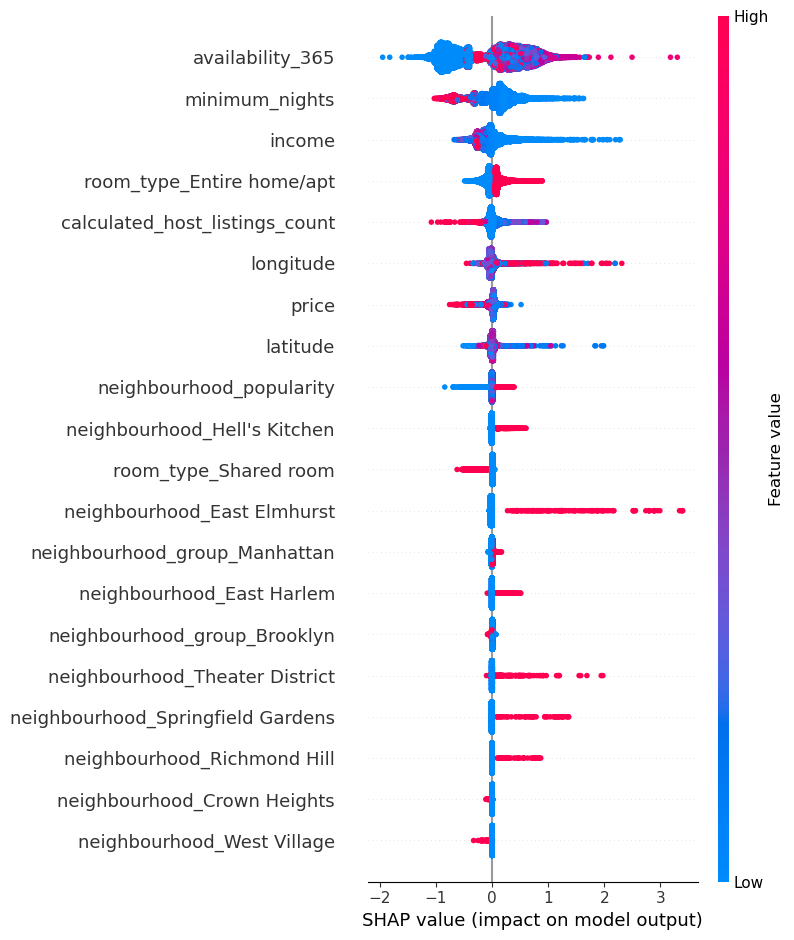

```
<function matplotlib.pyplot.show(close=None, block=None)>
```

```python
shap.summary_plot(train_lgbm_shap_values, X_train_transformed, feature_names = column_names)
plt.show
```

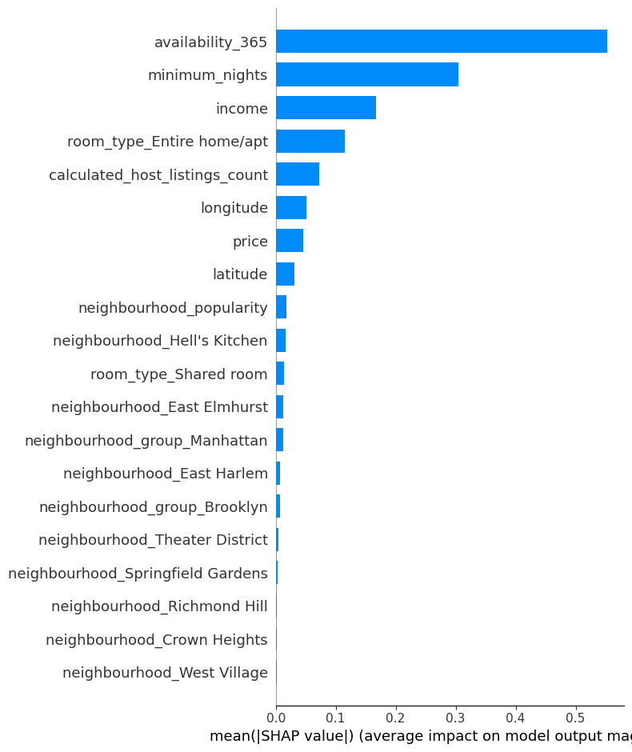

```python
shap.summary_plot(train_lgbm_shap_values, X_train_transformed, feature_names = column_names, plot_type="bar")
```

From the SHAP score and shap plot above we see that the most important 3 features for the LightGBM model is

## 12. Results on the test set

```python
pipe_lgbm = make_pipeline(ct, LGBMRegressor(n_estimators = 301, max_depth = 17, learning_rate =0.1, random_state =123))

pipe_lgbm.fit(X_train, y_train_transformed)
```

```
Pipeline(steps=[('columntransformer',
                 ColumnTransformer(transformers=[('pipeline',
                                                  Pipeline(steps=[('simpleimputer',
                                                                   SimpleImputer(strategy='median')),
                                                                  ('standardscaler',
                                                                   StandardScaler())]),
                                                  ['latitude', 'longitude',
                                                   'price', 'minimum_nights',
                                                   'calculated_host_listings_count',
                                                   'availability_365', 'income',
                                                   'neighbourhood_popularity']),
                                                 ('onehotencoder',
                                                  OneHotEncoder(handle_unknown='ignore',
                                                                sparse_output=False),
                                                  ['neighbourhood_group',
                                                   'neighbourhood',
                                                   'room_type']),
                                                 ('drop', 'drop',
                                                  ['name', 'host_id',
                                                   'host_name',
                                                   'number_of_reviews',
                                                   'last_review'])])),
                ('lgbmregressor',
                 LGBMRegressor(max_depth=17, n_estimators=301,
                               random_state=123))])
```

```python
preds = pipe_lgbm.predict(X_test)
#MSE Score
mse_test = mean_squared_error(y_test_transformed, preds)

#RMSE score
rmse_test = np.sqrt(mean_squared_error(y_test_transformed, preds))

#R^2 score
r2_test = r2_score(y_test_transformed, preds)

test_results_df = pd.DataFrame(
    data = [["Mean Squared Error",mse_test],["Root Mean Squared Error", rmse_test],["R-Squared Score",r2_test]],
    columns = ["Metric","Score"]
)

test_results_df
```

|  | Metric | Score |
| --- | --- | --- |
| 0 | Mean Squared Error | 1.484288 |
| 1 | Root Mean Squared Error | 1.218314 |
| 2 | R-Squared Score | 0.387176 |

The R^2 score is the one `sklearn` calls when we score, so the R^2 of both validation set and the test is almost equal around 0.38, indicating that the model's explanatory power is consistent between the validation and test sets. Also we see there is error in the model.

```python
X_train_enc = pd.DataFrame(
    data=ct.fit_transform(X_train),
    columns=column_names,
    index=X_train.index,
)

X_train_enc.columns = X_train_enc.columns.str.replace('[^a-zA-Z0-9_]', '_', regex = True)
X_train_enc.columns = X_train_enc.columns.str.replace(' ', '_')

lgbm_shap = LGBMRegressor(n_estimators = 301, max_depth = 17, learning_rate =0.1, random_state =123)
lgbm_shap.fit(X_train_enc, y_train_transformed)

X_train_enc.head(3)
```

| id | latitude | longitude | price | minimum_nights | calculated_host_listings_count | availability_365 | income | neighbourhood_popularity | neighbourhood_group_Bronx | neighbourhood_group_Brooklyn | ... | neighbourhood_Williamsbridge | neighbourhood_Williamsburg | neighbourhood_Windsor_Terrace | neighbourhood_Woodhaven | neighbourhood_Woodlawn | neighbourhood_Woodrow | neighbourhood_Woodside | room_type_Entire_home_apt | room_type_Private_room | room_type_Shared_room |
| --- | --- | --- | --- | --- | --- | --- | --- | --- | --- | --- | --- | --- | --- | --- | --- | --- | --- | --- | --- | --- | --- |
| 28736148 | 1.896525 | 0.166302 | -0.234668 | -0.143631 | -0.185406 | -0.726886 | -0.089234 | -0.562553 | 0.0 | 0.0 | ... | 0.0 | 0.0 | 0.0 | 0.0 | 0.0 | 0.0 | 0.0 | 1.0 | 0.0 | 0.0 |
| 34613254 | 0.590461 | -0.885425 | -0.006459 | 1.062979 | 0.397589 | 1.670044 | 0.341446 | 0.449751 | 0.0 | 0.0 | ... | 0.0 | 0.0 | 0.0 | 0.0 | 0.0 | 0.0 | 0.0 | 1.0 | 0.0 | 0.0 |
| 11144496 | -0.329211 | 0.024095 | 0.204846 | -0.282855 | -0.185406 | -0.856244 | -0.108486 | 1.377534 | 0.0 | 1.0 | ... | 0.0 | 1.0 | 0.0 | 0.0 | 0.0 | 0.0 | 0.0 | 0.0 | 1.0 | 0.0 |

3 rows × 234 columns

```python
X_test_enc = pd.DataFrame(
    data=ct.transform(X_test),
    columns=column_names,
    index=X_test.index,
)

X_test_enc.columns = X_test_enc.columns.str.replace('[^a-zA-Z0-9_]', '_', regex = True)
X_test_enc.columns = X_test_enc.columns.str.replace(' ', '_')

X_test_enc.head()
```

| id | latitude | longitude | price | minimum_nights | calculated_host_listings_count | availability_365 | income | neighbourhood_popularity | neighbourhood_group_Bronx | neighbourhood_group_Brooklyn | ... | neighbourhood_Williamsbridge | neighbourhood_Williamsburg | neighbourhood_Windsor_Terrace | neighbourhood_Woodhaven | neighbourhood_Woodlawn | neighbourhood_Woodrow | neighbourhood_Woodside | room_type_Entire_home_apt | room_type_Private_room | room_type_Shared_room |
| --- | --- | --- | --- | --- | --- | --- | --- | --- | --- | --- | --- | --- | --- | --- | --- | --- | --- | --- | --- | --- | --- |
| 22367196 | -0.641332 | 0.859589 | -0.492460 | -0.190039 | -0.185406 | -0.856244 | -0.118427 | 0.489414 | 0.0 | 1.0 | ... | 0.0 | 0.0 | 0.0 | 0.0 | 0.0 | 0.0 | 0.0 | 0.0 | 1.0 | 0.0 |
| 1725295 | 0.334824 | -0.571140 | -0.281155 | -0.282855 | -0.185406 | -0.742105 | -0.120520 | -0.948441 | 0.0 | 0.0 | ... | 0.0 | 0.0 | 0.0 | 0.0 | 0.0 | 0.0 | 0.0 | 0.0 | 1.0 | 0.0 |
| 10938202 | -1.608135 | -0.310319 | -0.407938 | -0.097223 | -0.185406 | -0.856244 | -0.100639 | -0.673098 | 0.0 | 1.0 | ... | 0.0 | 0.0 | 0.0 | 0.0 | 0.0 | 0.0 | 0.0 | 0.0 | 1.0 | 0.0 |
| 501693 | 1.211401 | -0.223306 | -0.221990 | -0.282855 | -0.185406 | 1.015644 | -0.119055 | 0.021127 | 0.0 | 0.0 | ... | 0.0 | 0.0 | 0.0 | 0.0 | 0.0 | 0.0 | 0.0 | 0.0 | 1.0 | 0.0 |
| 33270782 | -0.906872 | 0.927555 | -0.323416 | -0.236447 | -0.185406 | -0.856244 | -0.113718 | 2.327054 | 0.0 | 1.0 | ... | 0.0 | 0.0 | 0.0 | 0.0 | 0.0 | 0.0 | 0.0 | 0.0 | 1.0 | 0.0 |

5 rows × 234 columns

```python
explainer = shap.TreeExplainer(lgbm_shap)
```

```python
lgbm_shap.predict(pd.DataFrame(X_test_enc.iloc[10]).T)
```

```
array([0.44625005])
```

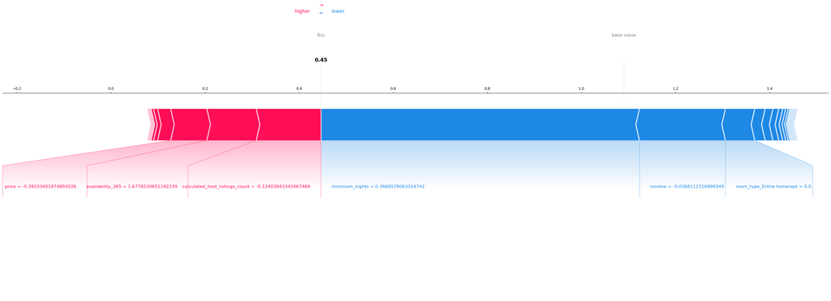

```python
test_instance100 = X_test_enc.iloc[10]

test_instance100 = test_instance100.values.reshape(1, -1)

shap_value100 = explainer.shap_values(test_instance100)

shap.force_plot(explainer.expected_value,
                shap_value100, test_instance100,
                matplotlib = True,
               feature_names = column_names,
               figsize = [40,10])
```

```python
lgbm_shap.predict(pd.DataFrame(X_test_enc.iloc[500]).T)
```

```
array([0.35837639])
```

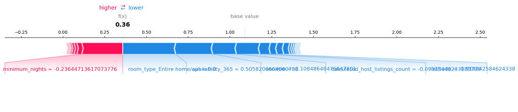

```python
test_instance500 = X_test_enc.iloc[500]

test_instance500 = test_instance500.values.reshape(1, -1)

shap_value500 = explainer.shap_values(test_instance500)

shap.force_plot(explainer.expected_value,
                shap_value500, test_instance500,
                matplotlib = True,
               feature_names = column_names,
               )
```

- The raw model prediction is much lower than the base value.
- Minimum nights = -0.23 is pushing the prediction towards higher score.
- room_type_Entire home/apt = 0.0 , availability_365 = 0.505, income = 0.-108 is pushing the prediction towards lower value.

## 13. Summary of results

```python
test_results_df
```

|  | Metric | Score |
| --- | --- | --- |
| 0 | Mean Squared Error | 1.484288 |
| 1 | Root Mean Squared Error | 1.218314 |
| 2 | R-Squared Score | 0.387176 |

## 14. Takeaway

My most significant takeaway from the supervised machine learning material is the crucial interplay between data quality, feature engineering, and model selection. In practice, the quality of the dataset is paramount, as it directly influences a model's performance. So we understood the importance of data preprocessing. Besides effective feature engineering, the process of selecting, transforming, and creating features, can significantly enhance a model's ability to capture patterns in the data. Moreover, the trade-off between model complexity and interpretability is a vital consideration; the right balance ensures the model's generalization and usability. Besides hyperparameter optimization, interpreting evaluation metrics can be time consuming and subjective. Overall, I learnt the importance and how much time it need to do feature engineering, model selection, preprocessing and generalization.